# Homework 04

## Question 1: Signal strength and correlated substitutes

Consider a regression problem with $n=120$ observations and $p=10$ covariates. Create one simulated dataset as follows. Generate the first covariate $X_1$ as $n$ independent standard normal draws. Then form the second covariate as

$$X_2 = 0.999X_1 + \sqrt{1-0.999^2}\,Z,$$

where $Z$ is another vector of $n$ independent standard normal draws, so that $X_1$ and $X_2$ have population correlation $0.999$. Generate the remaining covariates $X_3,\ldots,X_{10}$ as independent standard normal vectors of length $n$.

Thus $X_1$ and $X_2$ are extremely highly correlated, while $X_3$ and $X_4$ are independent of one another and of the remaining covariates. Finally, generate the response as

$$Y
=
0.15X_1
+0.15X_2
+0.30X_3
+0.15X_4
+\epsilon,$$

where $\epsilon$ is a vector of $n$ independent standard normal errors, independent of the covariates. Both members of the correlated pair appear in the generating equation with the same coefficient, even though each one carries almost the same observed information as the other. The two independent signals $X_3$ and $X_4$ have coefficients that differ by a factor of two, and $X_5,\ldots,X_{10}$ have zero coefficients.

Use seed `43246` and independently repeat the complete data generation and fitting procedure 200 times. Within each repetition, center and standardize the covariates using divisor $n$ and center the response. Fit the lasso model with the `glmnet` package in R or `sklearn.linear_model.Lasso` in Python, without scaling the variables inside the fitting function, at

$$\lambda\in\{0.08,0.12,0.18,0.24\}.$$

Fit all four penalties to the same generated dataset before beginning the next repetition. Leave the intercept unpenalized and convert the fitted slopes back to the original covariate scale. Store the slopes in one array whose dimensions correspond to the 200 repetitions, 10 covariates, and four penalties. Treat a slope as nonzero when its absolute value exceeds $10^{-8}$. Use `tol=1e-10, max_iter=100000` in Python. Verify that all 800 fits converge.

**Show the workflow**

```python
import warnings
import numpy as np
import pandas as pd
import matplotlib.pyplot as plt
from sklearn.linear_model import Lasso, ElasticNet
from sklearn.exceptions import ConvergenceWarning

warnings.simplefilter("error", ConvergenceWarning)   # any non-convergence raises

np.random.seed(43246)
n, p, reps = 120, 10, 200
lams = [0.08, 0.12, 0.18, 0.24]
rho = 0.999

datasets = []
for _ in range(reps):
    X = np.empty((n, p))
    X[:, 0] = np.random.normal(size=n)
    Z = np.random.normal(size=n)
    X[:, 1] = rho * X[:, 0] + np.sqrt(1 - rho**2) * Z
    X[:, 2:] = np.random.normal(size=(n, p - 2))
    eps = np.random.normal(size=n)
    y = 0.15 * X[:, 0] + 0.15 * X[:, 1] + 0.30 * X[:, 2] + 0.15 * X[:, 3] + eps
    datasets.append((X, y))

def fit_all(make_model):
    B = np.zeros((reps, p, len(lams)))          # repetitions x covariates x penalties
    n_fits = 0
    for r, (X, y) in enumerate(datasets):
        xbar = X.mean(axis=0)
        s = np.sqrt(((X - xbar) ** 2).mean(axis=0))      # divisor n
        Xs, yc = (X - xbar) / s, y - y.mean()
        for l, lam in enumerate(lams):
            m = make_model(lam).fit(Xs, yc)
            assert m.n_iter_ < 100000
            B[r, :, l] = m.coef_ / s                     # back to the original scale
            n_fits += 1
    print("Fits converged:", n_fits)
    return B

B_lasso = fit_all(lambda a: Lasso(alpha=a, fit_intercept=False, tol=1e-10, max_iter=100000))

names = [f"X{j}" for j in range(1, p + 1)]
def summaries(B):
    sel = pd.DataFrame((np.abs(B) > 1e-8).mean(axis=0), index=names, columns=lams)
    mag = pd.DataFrame(np.abs(B).mean(axis=0), index=names, columns=lams)
    return sel, mag

def line_plot(df, ylabel):
    plt.figure(figsize=(6.5, 4.2))
    for j, nm in enumerate(names):
        noise = j >= 4
        plt.plot(lams, df.loc[nm], marker="o", markersize=3,
                 color="lightgray" if noise else f"C{j}", lw=1 if noise else 2,
                 label=None if (noise and nm != "X5") else ("X5-X10" if noise else nm))
    plt.xlabel(r"$\lambda$"); plt.ylabel(ylabel); plt.legend(); plt.tight_layout(); plt.show()
```

```
Fits converged: 800
```

1. For every covariate and penalty, report the selection frequency and the mean absolute fitted slope, where the mean includes fitted zeros. Draw one figure for each summary. Explain how increasing the penalty changes the fitted magnitudes and selection frequencies.

**Show the workflow**

```
Selection frequency (lasso)
      0.08   0.12   0.18   0.24
X1   0.560  0.555  0.505  0.390
X2   0.470  0.465  0.425  0.350
X3   0.995  0.955  0.860  0.700
X4   0.740  0.580  0.380  0.175
X5   0.380  0.210  0.070  0.015
X6   0.355  0.195  0.045  0.005
X7   0.360  0.250  0.050  0.010
X8   0.340  0.140  0.045  0.010
X9   0.365  0.205  0.060  0.005
X10  0.360  0.170  0.040  0.005

Mean absolute slope (lasso)
       0.08    0.12    0.18    0.24
X1   0.1221  0.1013  0.0700  0.0435
X2   0.0959  0.0766  0.0509  0.0267
X3   0.2091  0.1691  0.1132  0.0661
X4   0.0799  0.0527  0.0234  0.0081
X5   0.0220  0.0103  0.0029  0.0006
X6   0.0190  0.0083  0.0016  0.0002
X7   0.0216  0.0098  0.0018  0.0003
X8   0.0157  0.0060  0.0015  0.0007
X9   0.0205  0.0094  0.0021  0.0002
X10  0.0177  0.0071  0.0015  0.0002
```

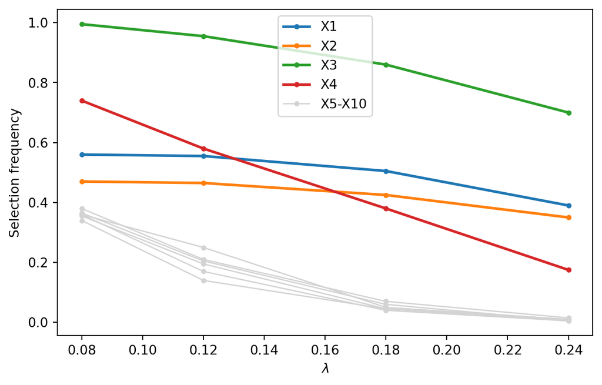

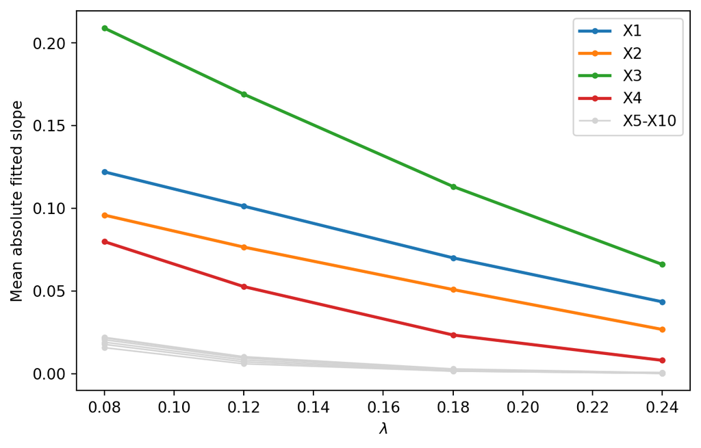

```python
sel_l, mag_l = summaries(B_lasso)
print("Selection frequency (lasso)"); print(sel_l.round(3))
print("\nMean absolute slope (lasso)"); print(mag_l.round(4))
line_plot(sel_l, "Selection frequency")
line_plot(mag_l, "Mean absolute fitted slope")
```

Raising $\lambda$ shrinks every fitted magnitude and lowers every selection frequency. The drop is steepest for weak or null covariates: noise covariates fall from about 0.36 selected at $\lambda=0.08$ to under 0.01 at $0.24$, $X_4$ (coefficient 0.15) from 0.74 to 0.18, while the strong $X_3$ (0.30) stays selected 70% of the time even at $0.24$.

2. For the pair $(X_1,X_2)$, report the frequency of four mutually exclusive outcomes at each penalty: only the first covariate is selected, only the second is selected, both are selected, and neither is selected. Compare the two marginal selection frequencies and explain why they are similar. Describe how the four outcomes shift as the penalty increases, and explain why lasso can produce a sparse fitted rule that omits one member of the pair even though both members appear in the generating equation.

**Show the workflow**

```python
def pair_outcomes(B):
    a, b = np.abs(B[:, 0, :]) > 1e-8, np.abs(B[:, 1, :]) > 1e-8
    return pd.DataFrame({"only X1": (a & ~b).mean(0), "only X2": (~a & b).mean(0),
                         "both": (a & b).mean(0), "neither": (~a & ~b).mean(0)}, index=lams)

out_l = pair_outcomes(B_lasso)
out_l
```

|  | only X1 | only X2 | both | neither |
| --- | --- | --- | --- | --- |
| 0.08 | 0.515 | 0.425 | 0.045 | 0.015 |
| 0.12 | 0.515 | 0.425 | 0.040 | 0.020 |
| 0.18 | 0.480 | 0.400 | 0.025 | 0.095 |
| 0.24 | 0.380 | 0.340 | 0.010 | 0.270 |

The marginals are similar ($0.56$ vs. $0.47$ at $\lambda=0.08$) because $X_1,X_2$ enter the model symmetrically and are almost interchangeable, so which one the lasso picks is close to a coin flip. As $\lambda$ grows, “only one” stays dominant while “neither” rises (0.015 to 0.27) and “both” nearly vanishes (0.045 to 0.01). With correlation $0.999$, one member alone can absorb the combined effect ($0.15+0.15$), and adding the second brings almost no fit improvement but costs extra $\ell_1$ penalty, so a sparse rule keeps only one.

3. Compare the selection frequencies of $X_3$ and $X_4$ with the average selection frequency among $X_5,\ldots,X_{10}$. Explain how signal magnitude and the penalty account for the pattern. Use the correlated pair to explain why a fitted zero does not establish that the corresponding population coefficient is zero, and why a nonzero fitted coefficient does not establish that the variable is uniquely important.

**Show the workflow**

```python
pd.DataFrame({"X3": sel_l.loc["X3"], "X4": sel_l.loc["X4"],
              "avg X5-X10": sel_l.loc[names[4:]].mean()}).round(3)
```

|  | X3 | X4 | avg X5-X10 |
| --- | --- | --- | --- |
| 0.08 | 0.995 | 0.740 | 0.360 |
| 0.12 | 0.955 | 0.580 | 0.195 |
| 0.18 | 0.860 | 0.380 | 0.052 |
| 0.24 | 0.700 | 0.175 | 0.008 |

Selection frequency follows signal size: $X_3$ (0.995 to 0.70) $>$ $X_4$ (0.74 to 0.175) $>$ noise (0.36 to 0.008), since a larger coefficient survives a larger soft-threshold, and a bigger penalty separates the groups more sharply. In the correlated pair, $X_1$ is often fitted at exactly zero although its true coefficient is $0.15$, because $X_2$ stood in for it; and when $X_1$ is nonzero it is not uniquely important, since $X_2$ could have been chosen instead.

## Question 2: Elastic net with an equal penalty mix

This question continues the simulation of Question 1. Generate the data exactly as in Question 1, with the same seed `43246`, so that the 200 repetitions produce the same datasets and the only change is the fitting method. Now fit the elastic net model with mixing parameter $\alpha=0.5$, which places equal weight on the $\ell_1$ and squared $\ell_2$ penalties. Use `sklearn.linear_model.ElasticNet` in Python (`l1_ratio=0.5`), with the same four penalties $\lambda\in\{0.08,0.12,0.18,0.24\}$ and the same fitting details as in Question 1.

**Show the workflow**

```python
B_enet = fit_all(lambda a: ElasticNet(alpha=a, l1_ratio=0.5, fit_intercept=False,
                                      tol=1e-10, max_iter=100000))
sel_e, mag_e = summaries(B_enet)
```

```
Fits converged: 800
```

1. For every covariate and penalty, report the selection frequency, and draw the selection-frequency figure. Compare the frequencies with the lasso results from Question 1: which covariates change the most, and in which direction?

**Show the workflow**

```
      0.08   0.12   0.18   0.24
X1   0.960  0.970  0.965  0.955
X2   0.970  0.990  0.970  0.960
X3   0.995  0.995  0.985  0.955
X4   0.870  0.825  0.710  0.580
X5   0.630  0.490  0.345  0.210
X6   0.630  0.510  0.305  0.185
X7   0.600  0.485  0.310  0.245
X8   0.630  0.485  0.295  0.135
X9   0.670  0.495  0.320  0.200
X10  0.640  0.500  0.325  0.165
```

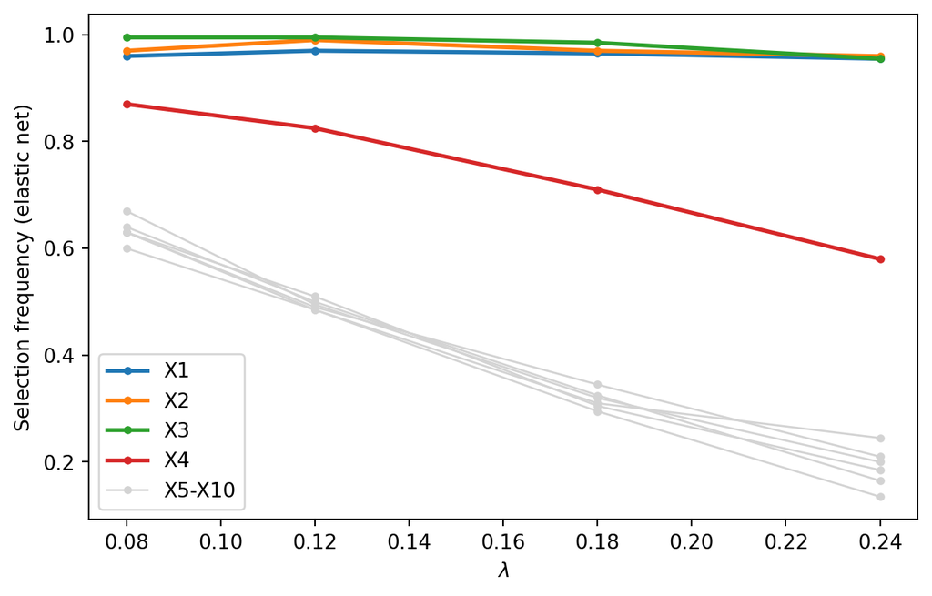

```
Change from lasso:
      0.08   0.12   0.18   0.24
X1   0.400  0.415  0.460  0.565
X2   0.500  0.525  0.545  0.610
X3   0.000  0.040  0.125  0.255
X4   0.130  0.245  0.330  0.405
X5   0.250  0.280  0.275  0.195
X6   0.275  0.315  0.260  0.180
X7   0.240  0.235  0.260  0.235
X8   0.290  0.345  0.250  0.125
X9   0.305  0.290  0.260  0.195
X10  0.280  0.330  0.285  0.160
```

```python
print(sel_e.round(3))
line_plot(sel_e, "Selection frequency (elastic net)")
print("\nChange from lasso:"); print((sel_e - sel_l).round(3))
```

2. For the pair $(X_1,X_2)$, report the frequency of four mutually exclusive outcomes at each penalty: only the first covariate is selected, only the second is selected, both are selected, and neither is selected. Compare these frequencies with Question 1. Are the two covariates now properly selected together? Explain why the squared $\ell_2$ part of the penalty encourages the fit to keep both members of the pair.

**Show the workflow**

```python
pair_outcomes(B_enet)
```

|  | only X1 | only X2 | both | neither |
| --- | --- | --- | --- | --- |
| 0.08 | 0.030 | 0.040 | 0.930 | 0.000 |
| 0.12 | 0.010 | 0.030 | 0.960 | 0.000 |
| 0.18 | 0.015 | 0.020 | 0.950 | 0.015 |
| 0.24 | 0.020 | 0.025 | 0.935 | 0.020 |

Yes: “both” is now selected 93-96% of the time (vs. 1-5% under the lasso), and “only one” is rare. The squared $\ell_2$ term penalizes an unequal split of weight between near-duplicate columns, so it is cheaper to share the effect across both than to load it on one (the grouping effect).

3. Compare the average selection frequency among the noise covariates $X_5,\ldots,X_{10}$ with the lasso results at each penalty. Are the noise covariates still screened out as the penalty increases? At the same numerical value of $\lambda$, the elastic net applies a weaker $\ell_1$ threshold than the lasso; use this to explain any difference. State the penalties at which the elastic net selects both members of the pair while screening out most noise covariates.

**Show the workflow**

```python
pd.DataFrame({"lasso": sel_l.loc[names[4:]].mean(), "elastic net": sel_e.loc[names[4:]].mean(),
              "EN: both X1,X2": pair_outcomes(B_enet)["both"]}).round(3)
```

|  | lasso | elastic net | EN: both X1,X2 |
| --- | --- | --- | --- |
| 0.08 | 0.360 | 0.633 | 0.930 |
| 0.12 | 0.195 | 0.494 | 0.960 |
| 0.18 | 0.052 | 0.317 | 0.950 |
| 0.24 | 0.008 | 0.190 | 0.935 |

Noise is still screened as $\lambda$ increases (0.63 to 0.19), but far more slowly than under the lasso (0.36 to 0.008), because the $\ell_1$ threshold is only $\alpha\lambda=0.5\lambda$. The elastic net selects both members of the pair and screens out most noise (at least 68%) at $\lambda=0.18$ (noise selected 0.32) and $\lambda=0.24$ (0.19); at $0.08$ and $0.12$ about half or more of the noise is still selected.

## Question 3: Coordinate descent and the lasso path

This question asks you to implement coordinate descent yourself and use it to compute a complete lasso path. Create one simulated dataset with $n=100$ observations and $p=3$ covariates. Generate three covariates as independent standard normal vectors of length $n$, and generate the response as

$$Y
=
1.5+X_1-2X_2+\epsilon,$$

where $\epsilon$ is a vector of $n$ independent standard normal errors, independent of the covariates. The third covariate does not appear in the generating equation. Use seed `43247`. Center the response and center and standardize each covariate using divisor $n$. The intercept is fitted separately as the mean of the response and is not penalized.

The lasso objective is

$$L_\lambda(\boldsymbol\beta)
=
\frac{1}{2n}
\left\lVert
\widetilde{\mathbf y}-\mathbf X\boldsymbol\beta
\right\rVert_2^2
+
\lambda\lVert\boldsymbol\beta\rVert_1,$$

where $\widetilde{\mathbf y}$ is the centered response and $\mathbf X$ is the standardized covariate matrix. Coordinate descent updates one slope at a time while holding the other slopes fixed. For coordinate $j$, form the residual that leaves covariate $j$ out of the current fit, and compute the score $a_j$ as the mean of the elementwise product of covariate $j$ and that residual. Because each standardized column satisfies $\frac{1}{n}\mathbf x_j^{\mathsf T}\mathbf x_j=1$, the update is the soft-thresholding rule from the Week 4 lecture:

$$\widehat\beta_j\leftarrow S(a_j,\lambda),
\qquad
S(a,\lambda)=\operatorname{sign}(a)(|a|-\lambda)_+.$$

Follow this procedure:

1. Fix a value of $\lambda$ and loop over the indices $j=1,\ldots,p$ until the coefficients stop changing. For each $j$, form the residual without covariate $j$, compute its score, and save the soft-thresholded value as the new $\widehat\beta_j$ before moving to the next index.
2. Check convergence after each complete cycle: stop when the largest absolute coefficient change is below a small tolerance, such as $10^{-8}$. Record the fitted vector for that $\lambda$.
3. Then reduce $\lambda$ to the next grid value and start the next fit from the current coefficients (a warm start). Repeat for the whole grid

$$\lambda\in\{2.5,2.0,1.5,1.0,0.6,0.4,0.25,0.15,0.08,0.03\}.$$

1. Implement the procedure. Report the fitted coefficient vector at each grid value in a small table, and verify that every fit converged. Compute $\lambda_{\max}=\lVert\frac{1}{n}\mathbf X^{\mathsf T}\widetilde{\mathbf y}\rVert_\infty$ and check that all slopes are zero for grid values at or above it.

**Show the workflow**

```python
np.random.seed(43247)
n3, p3 = 100, 3
X3 = np.random.normal(size=(n3, p3))
eps3 = np.random.normal(size=n3)
y3 = 1.5 + X3[:, 0] - 2 * X3[:, 1] + eps3

Xc = X3 - X3.mean(axis=0)
Xs3 = Xc / np.sqrt((Xc ** 2).mean(axis=0))
yc3 = y3 - y3.mean()

def soft(a, lam):
    return np.sign(a) * max(abs(a) - lam, 0.0)

grid = [2.5, 2.0, 1.5, 1.0, 0.6, 0.4, 0.25, 0.15, 0.08, 0.03]
beta = np.zeros(p3)                        # warm start carried along the grid
path, cycles = [], []
for lam in grid:
    for it in range(1, 100001):
        old = beta.copy()
        for j in range(p3):
            r = yc3 - Xs3 @ beta + Xs3[:, j] * beta[j]     # residual without covariate j
            beta[j] = soft(np.mean(Xs3[:, j] * r), lam)
        if np.max(np.abs(beta - old)) < 1e-8:
            break
    assert it < 100000
    path.append(beta.copy()); cycles.append(it)

path = np.array(path)
lam_max = np.max(np.abs(Xs3.T @ yc3 / n3))
print(pd.DataFrame(path, index=grid, columns=["beta1", "beta2", "beta3"]).assign(cycles=cycles).round(4))
print("All fits converged (max cycles):", max(cycles))
print("lambda_max:", round(lam_max, 4))
print("All slopes zero for grid values >= lambda_max:",
      all(np.all(path[i] == 0) for i, g in enumerate(grid) if g >= lam_max))
```

```
       beta1   beta2  beta3  cycles
2.50  0.0000 -0.0000    0.0       1
2.00  0.0000 -0.1270    0.0       2
1.50  0.0000 -0.6270    0.0       2
1.00  0.0000 -1.1270    0.0       2
0.60  0.3223 -1.5657    0.0       6
0.40  0.5495 -1.7930    0.0       6
0.25  0.7200 -1.9635    0.0       6
0.15  0.8336 -2.0771    0.0       6
0.08  0.9132 -2.1566    0.0       6
0.03  0.9700 -2.2135    0.0       6
All fits converged (max cycles): 6
lambda_max: 2.127
All slopes zero for grid values >= lambda_max: True
```

All ten fits converged within 6 cycles. $\lambda_{\max}\approx2.127$, and the only grid value at or above it ($\lambda=2.5$) gives all-zero slopes, as expected.

2. Plot the coefficient path: one curve per covariate, with the fitted slope on the vertical axis and $\log(\lambda)$ on the horizontal axis. Describe the order in which the covariates enter the model and explain that order using the sizes of the true coefficients.

**Show the workflow**

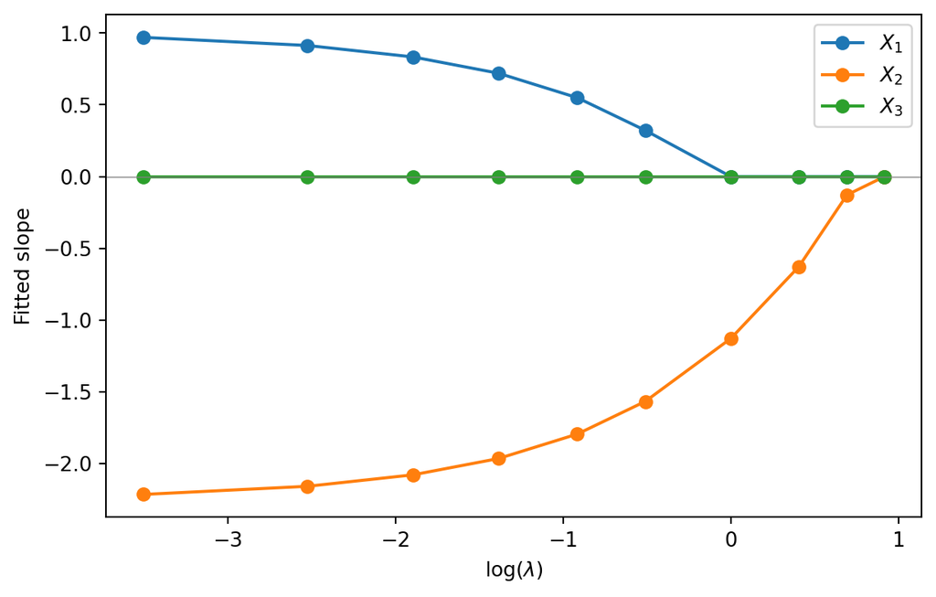

```python
plt.figure(figsize=(6.5, 4.2))
for j in range(p3):
    plt.plot(np.log(grid), path[:, j], marker="o", label=f"$X_{j+1}$")
plt.axhline(0, color="gray", lw=0.5)
plt.xlabel(r"$\log(\lambda)$"); plt.ylabel("Fitted slope"); plt.legend(); plt.tight_layout(); plt.show()
```

$X_2$ enters first (just below $\lambda_{\max}\approx2.13$), then $X_1$ (between $\lambda=1.0$ and $0.6$); $X_3$ never enters. The order matches the true coefficient magnitudes ($|-2|>|1|>0$): a larger effect has a larger score $a_j$, so it clears the threshold $\lambda$ earlier.

3. The third covariate has a zero population coefficient. Does it enter the path at small penalties in your run? Compare the fit at the smallest grid value with a least-squares fit on the same standardized data, and explain why the two are close but not identical.

**Show the workflow**

```python
ols3 = np.linalg.lstsq(Xs3, yc3, rcond=None)[0]
print("lasso, lambda=0.03:", np.round(path[-1], 4))
print("OLS:               ", np.round(ols3, 4))
```

```
lasso, lambda=0.03: [ 0.97   -2.2135  0.    ]
OLS:                [ 1.0076 -2.2445  0.0283]
```

No: $\widehat\beta_3$ stays exactly zero even at $\lambda=0.03$ (its OLS estimate is only $0.028$, below the threshold). The lasso fit at $\lambda=0.03$ is close to OLS but slightly shrunk toward zero (e.g. $-2.21$ vs. $-2.24$), since the soft-threshold subtracts about $\lambda$ from each score; they would coincide only as $\lambda\to0$.

## Question 4: Tuning and comparing penalized regressions for diabetes prediction

The supplied `data/diabetes.csv` contains 442 observations of ten baseline covariates and the quantitative response `y`. The file `data/diabetes-split-folds.csv` assigns 353 observations to the training set and 89 observations to the final test set; it also supplies ten fold labels for the training observations.

Tune three penalized regressions (lasso, ridge, and elastic net with mixing parameter $\alpha=0.5$) for predicting `y` from the ten covariates. Using only the training observations, perform ten-fold cross-validation with the supplied folds for each method and select each penalty by the smallest mean cross-validation error. In Python, use `GridSearchCV` with 61 logarithmically spaced penalty values from $10^{-4}$ to $10^2$ for each method, placing `StandardScaler` inside a `Pipeline`. In every fit, estimate the covariate means and scales from the observations used for that fit, center the response, and leave the intercept unpenalized.

Select the method with the smallest minimum cross-validation error. Produce the cross-validation plot for each of the three fits and a table comparing the three selected penalties and their cross-validation errors. Then refit the chosen model on all training observations, evaluate the final test set once, and report the selected method, its penalty, and the test error.

**Show the workflow**

```
     method  selected penalty  min CV MSE
      lasso            0.1000   3071.2469
      ridge            0.5012   3073.4858
elastic net            0.0032   3073.4487
```

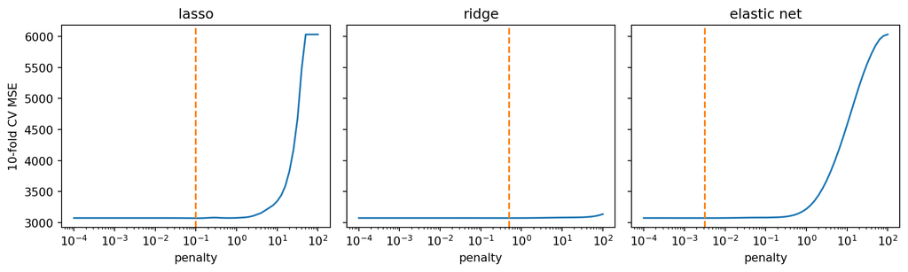

```
Selected: lasso, penalty = 0.1000, test MSE = 2732.41
```

```python
from sklearn.pipeline import Pipeline
from sklearn.preprocessing import StandardScaler
from sklearn.linear_model import Ridge
from sklearn.model_selection import GridSearchCV, PredefinedSplit

diab = pd.read_csv("data/diabetes.csv")
split = pd.read_csv("data/diabetes-split-folds.csv")
assert (split["row_id"].to_numpy() == np.arange(1, len(diab) + 1)).all()   # rows match by position

is_train = (split["split"] == "train").to_numpy()
X_all = diab.drop(columns="y").to_numpy()
y_all = diab["y"].to_numpy()
X_tr, y_tr, X_te, y_te = X_all[is_train], y_all[is_train], X_all[~is_train], y_all[~is_train]
folds_tr = PredefinedSplit(split.loc[is_train, "cv_fold"].astype(int).to_numpy())

alphas = np.logspace(-4, 2, 61)
models = {"lasso": Lasso(tol=1e-10, max_iter=100000),
          "ridge": Ridge(),
          "elastic net": ElasticNet(l1_ratio=0.5, tol=1e-10, max_iter=100000)}

searches, rows = {}, []
for name, est in models.items():
    gs = GridSearchCV(Pipeline([("scale", StandardScaler()), ("fit", est)]),
                      {"fit__alpha": alphas}, cv=folds_tr,
                      scoring="neg_mean_squared_error", refit=True).fit(X_tr, y_tr)
    searches[name] = gs
    rows.append((name, gs.best_params_["fit__alpha"], -gs.best_score_))

cv_table = pd.DataFrame(rows, columns=["method", "selected penalty", "min CV MSE"])
print(cv_table.round(4).to_string(index=False))

fig, axes = plt.subplots(1, 3, figsize=(11, 3.4), sharey=True)
for ax, (name, gs) in zip(axes, searches.items()):
    ax.plot(alphas, -gs.cv_results_["mean_test_score"])
    ax.axvline(gs.best_params_["fit__alpha"], color="C1", linestyle="--")
    ax.set_xscale("log"); ax.set_title(name); ax.set_xlabel("penalty")
axes[0].set_ylabel("10-fold CV MSE")
plt.tight_layout(); plt.show()

best = cv_table.loc[cv_table["min CV MSE"].idxmin()]
test_mse = np.mean((y_te - searches[best["method"]].predict(X_te)) ** 2)   # test set used once
print(f"\nSelected: {best['method']}, penalty = {best['selected penalty']:.4f}, "
      f"test MSE = {test_mse:.2f}")
```

The lasso has the smallest cross-validated error ($\approx3071$ at penalty $0.1$) and is selected; refit on all training data, its test MSE is $\approx2732$. The three CV errors differ by only about $2$ out of $3000$, so the choice among methods is not meaningful here — the test set was used only once, after the method and penalty were fixed. (Penalty values are not comparable across methods: scikit-learn’s `Ridge` penalty is not divided by $n$ while the `Lasso` and `ElasticNet` penalties are.)